# Praca domowa nr 2

Martyna Majchrzak

7 04 2021

## Zbiór danych

Zbiór danych Diabetes zawiera informacje o osobach chorych na cukrzycę.

1. preg - ile razy dana osoba była w ciąży
2. plas - stężenie glukozy w osoczu po 2h ustnego testu na tolerancję glukozy
3. pres - ciśnienie rozkurczowe (mm Hg)
4. skin - grubość skóry mierzona na tricepsie (mm)
5. insu - 2-Hour serum insulin (mu U/ml)
6. mass - index masy ciała BMI (waga w kg/(wzrost w m)^2)
7. pedi - obciążenie genetyczne (Diabetes pedigree function)
8. age - wiek (lata)
9. class - zmienna celu o wartościach tested_negative oraz tested_positive

## Rozkłady zmiennych

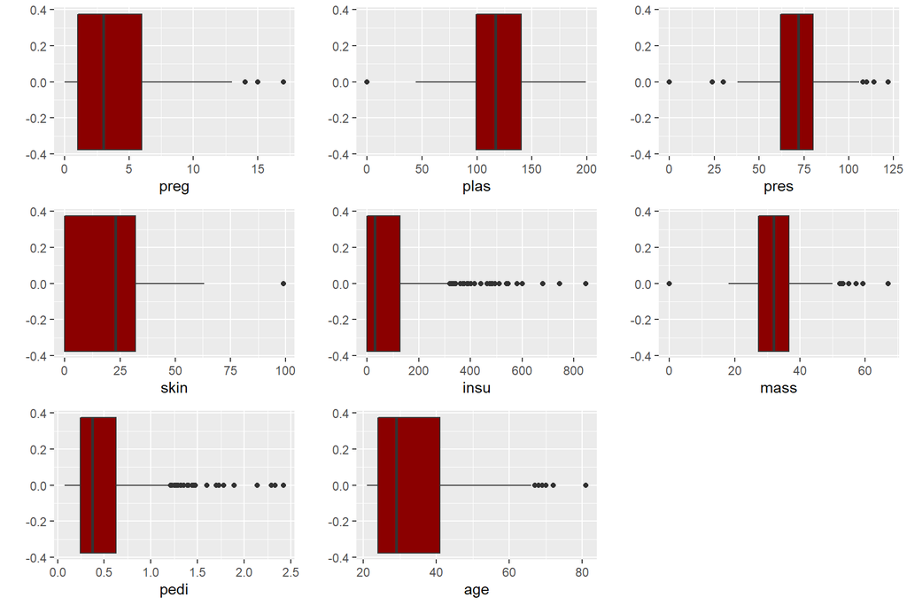

## Tworzenie modelu i explainera

W rozwiązaniu zostanie użyty model Random Forest. Według danych OpenML ( https://www.openml.org/t/37 ) osiąga on średnio największą wartość miary accuracy.

```
## Preparation of a new explainer is initiated
##   -> model label       :  ranger  (  default  )
##   -> data              :  768  rows  8  cols
##   -> target variable   :  768  values
##   -> predict function  :  yhat.ranger  will be used (  default  )
##   -> predicted values  :  No value for predict function target column. (  default  )
##   -> model_info        :  package ranger , ver. 0.12.1 , task classification (  default  )
##   -> predicted values  :  numerical, min =  0 , mean =  0.3491104 , max =  0.953319
##   -> residual function :  difference between y and yhat (  default  )
##   -> residuals         :  numerical, min =  -0.5822087 , mean =  -0.0001521111 , max =  0.6520325
##   A new explainer has been created!
```

## Predykcja dla obserwacji 13

Przyjrzyjmy się pacjentce ze szczęśliwym numerem 13.

|  | preg | plas | pres | skin | insu | mass | pedi | age | class |
| --- | --- | --- | --- | --- | --- | --- | --- | --- | --- |
| 12 | 10 | 139 | 80 | 0 | 0 | 27.1 | 1.441 | 57 | tested_negative |

Jest to 57-latka która była w ciąży 10 razy i ma BMI 27,1 (nadwaga).

```
##      tested_negative tested_positive
## [1,]       0.7534169       0.2465831
```

Ta osoba z prawdopodobieństwem ok. 0.75 została przypisana do klasy tested_negative (czyli 0.25 do tested_positive)

## LIME

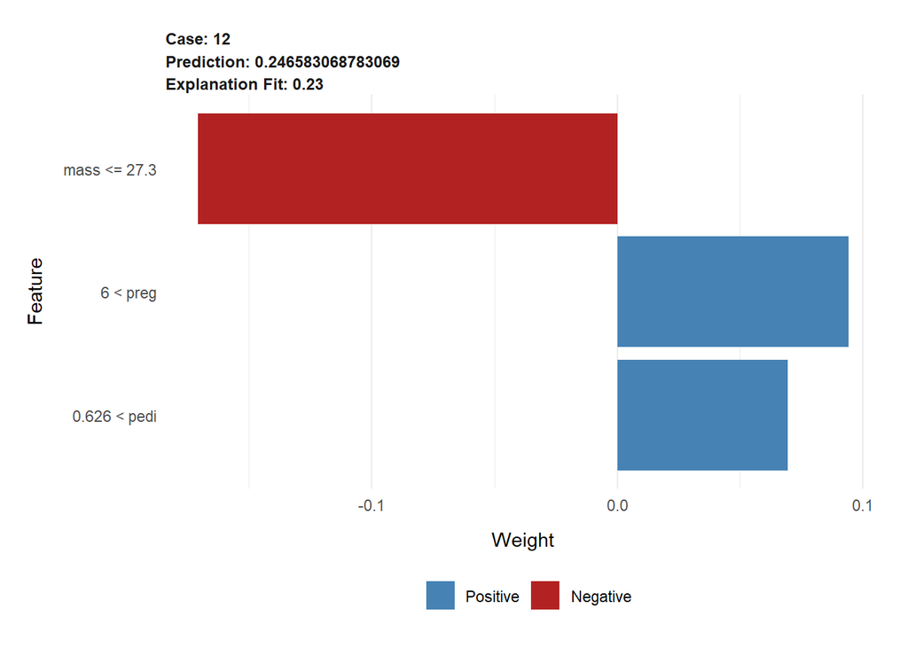

Według wyjaśnienia prawdopodobieństwo pozytywnego testu obniżał fakt, że pacjentka miała BMI poniżej 27,3, a podwyższała wartość funkcji obciążenia genetycznego większa od 0,626 i to, że pacjentka była w ciąży więcej niż 6 razy.

Podejrzany wydaje się fakt, że mimo nadwagi zmienna mass obniżała tak znacznie ryzyko wystąpienia cukrzycy. Przyjrzyjmy się rozkładowi tej zmiennej.

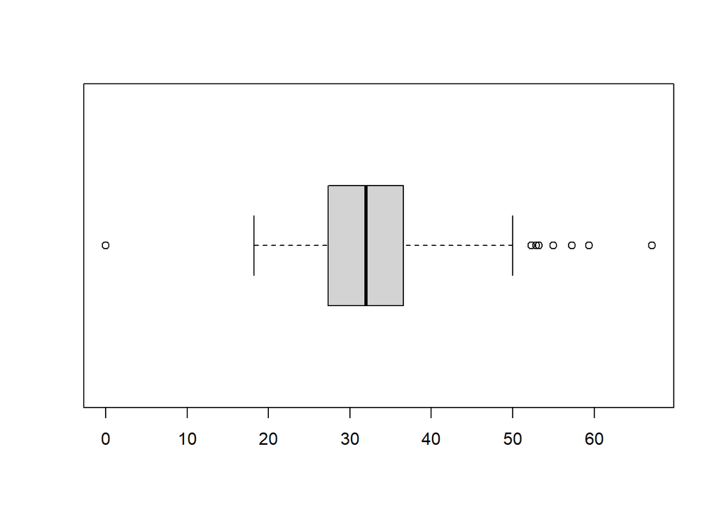

```
## [1] 31.99258
```

Średnia zmiennej mass wynosi prawie 32, co oznacza otyłość, zdarzają się też przypadki powyżej 40, co oznacza otyłość kliniczną.

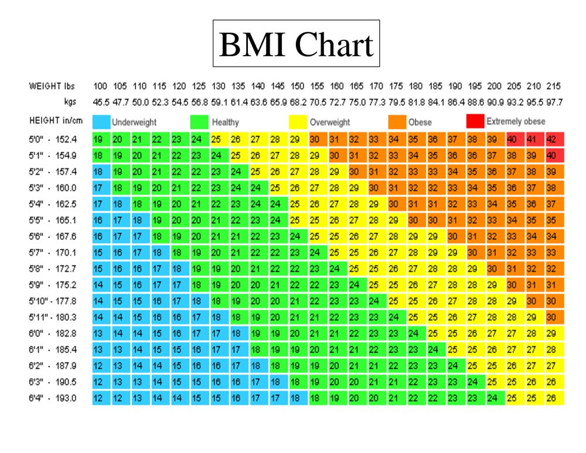

BMI chart

Zatem nasza pacjentka na tym tle nie wypada tak źle.

## LIME dla różnych obserwacji

### Obserwacja 26

|  | preg | plas | pres | skin | insu | mass | pedi | age | class |
| --- | --- | --- | --- | --- | --- | --- | --- | --- | --- |
| 25 | 10 | 125 | 70 | 26 | 115 | 31.1 | 0.205 | 41 | tested_positive |

Pacjentka ma 41 lat, była w ciąży 10 razy, ma BMI 31,1 i chorowała na cukrzycę.

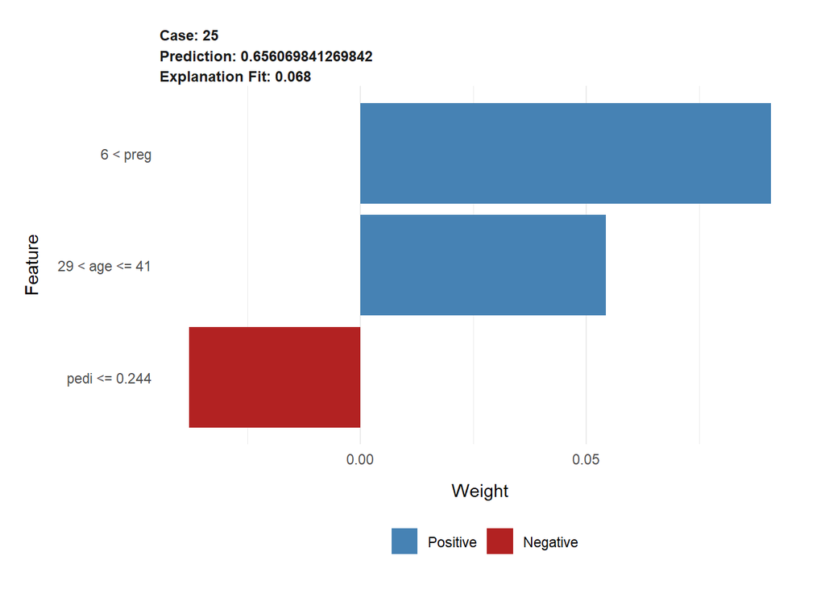

Tą pacjentkę model z prawdopodobieństwem 65% zaklasyfikowałby jako chorą, na co wpływa ponownie duża liczba ciąży oraz wiek powyżej 29 lat. Tym razem wartość funkcji obciążenia genetycznego jest jednak dość niska, co obniża prawdopodobieństwo wystąpienia cukrzycy.

### Obserwacja 39

|  | preg | plas | pres | skin | insu | mass | pedi | age | class |
| --- | --- | --- | --- | --- | --- | --- | --- | --- | --- |
| 38 | 2 | 90 | 68 | 42 | 0 | 38.2 | 0.503 | 27 | tested_positive |

Pacjentka ma 27 lat, była w ciąży 2 razy, ma BMI 382, i chorowała na cukrzycę.

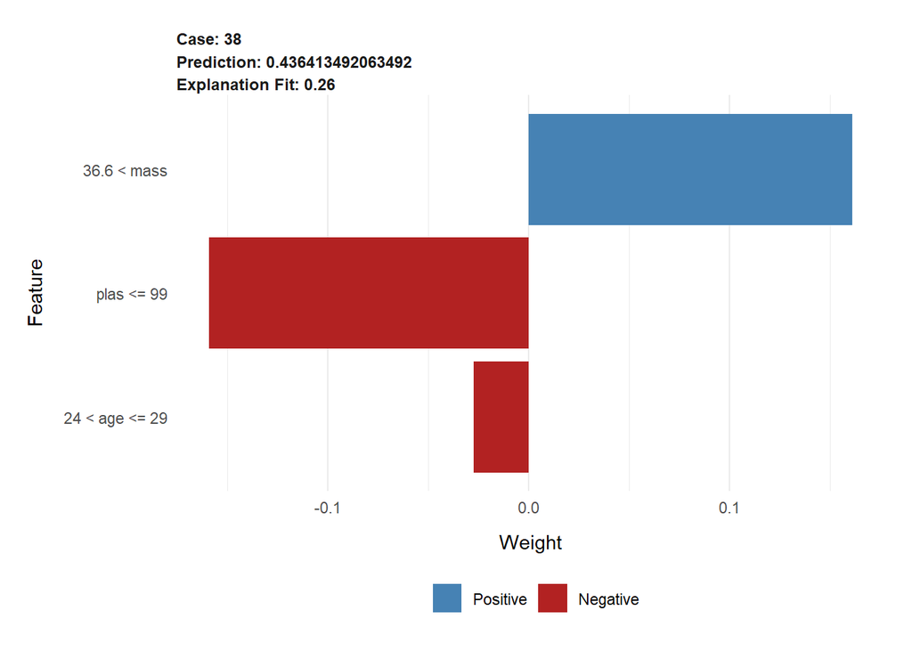

### Obserwacja 52

|  | preg | plas | pres | skin | insu | mass | pedi | age | class |
| --- | --- | --- | --- | --- | --- | --- | --- | --- | --- |
| 51 | 1 | 101 | 50 | 15 | 36 | 24.2 | 0.526 | 26 | tested_negative |

Pacjentka ma 26 lat, była w ciąży 1 raz, ma BMI 24,2 (prawidłowe!), i nie chorowała na cukrzycę.

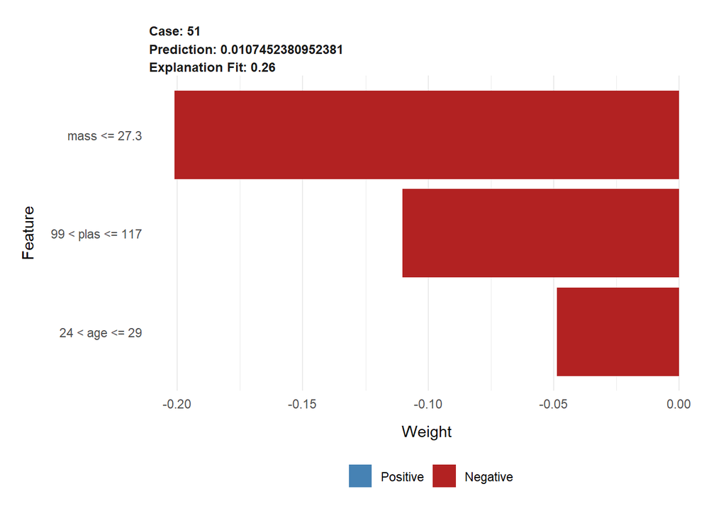

### Wnioski

Dla różnych obserwacji istone były różne zmienne, lecz zawsze to była jedna spomiędzy: `mass`, `plas`, `age`, `preg` i `pedi`.

Zawsze też konsekwetnie niska/wysoka wartość danej zmiennej analogicznie wpływała na predykcję, dla wszystkich w tych 5 zmiennych im wyższa wartość tym wyższe prawdopodobieństwo zachorowania.

## LIME oraz SHAP dla obserwacji 13

Dopasujmy teraz LIME z 8 zamiast 3 zmiennych,aby łatwiej było porównać go z SHAP.

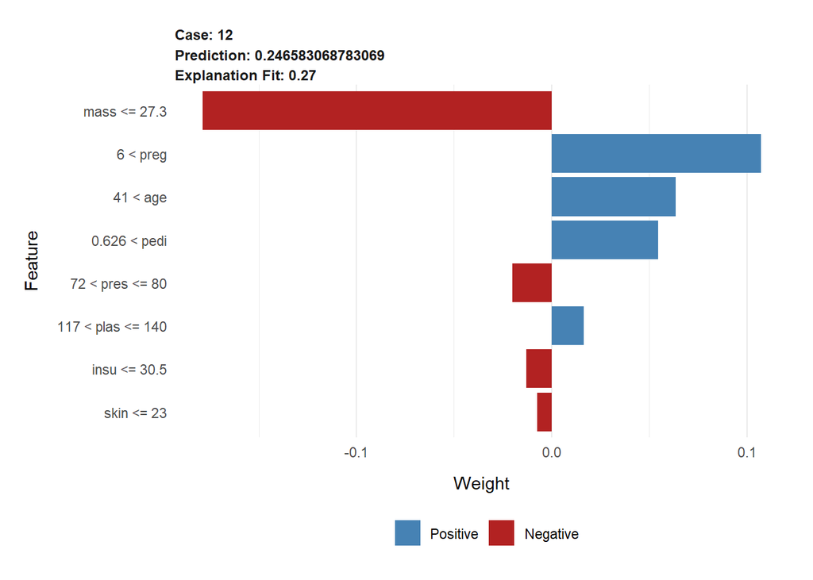

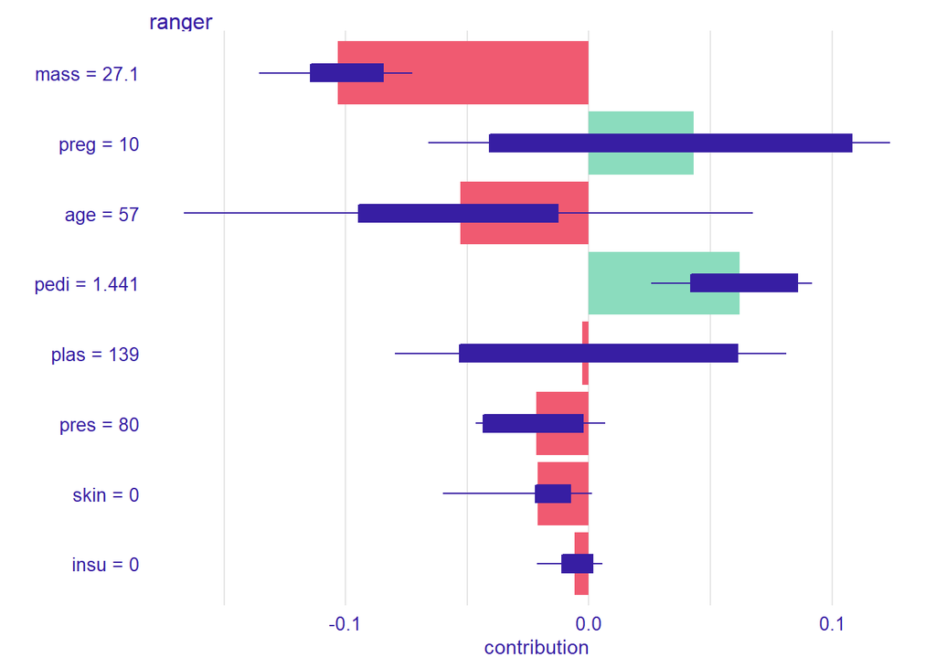

W obu wyjaśnieniach najbardziej pływającą na predykcję zmienną jest `mass`, o stosunkowo niskiej wartości. W obu przypadkach zmienne `preg` i `pedi` podwyższają prawdopodobieństwo zakwalifikowania pacjentki jako chorej. Wyraźną różnicę widać jednak w zmiennych: - `age` - według LIME wiek > 41 znacznie zwiększa ryzyko zachorowania, a według BreakDown wiek 57lat nieznacznie je obniża - `plas` - według LIME stężenie glukozy między 117 a 140 zwiększa ryzyko zachorowania, a według wynik 139 bardzo, bardzo niewiele, ale jednak obniża.